# GLM for binary data

Laure

8 jan 2020

# Binary Data

## Binary data

Binary data may occur in two forms

- ungrouped in which the variable can take one of two values, say success/failure
- grouped in which the variable is the number of successes in a given number of trials

The natural distribution for such data is the Binomial(n,p) distribution, where in the ﬁrst case n = 1

## Models for binary data

Suppose $Yi ∼ Binomial(n_i,p_i)$ and we wish to model the proportions $Y_i/n_i$. Then
$$E(Y_i/n_i) = p_i$$
$$var(Y_i/n_i) = \frac{1}{n_i} p_i(1 − p_i)$$
So our variance function is $V(µ_i) = µ_i(1−µ_i)$ Our link function must map from (0,1)→(−∞,∞). A common choice is $g(µi) = logit(µi) = log(\frac{µi}{1−µi})$.

Binomial data can be modelled by a GLM, with the canonical logit link. This model is known as the logistic regression model and is the most popular for binary data. There are two other links commonly used in practice

- probit link $g(µ_i) = Φ^{−1}(µ_i)$ where $Φ$ denotes the cumulative distribution function of N(0,1)
- complementary log-log link $g(µ_i) = log(−log(1−µ_i))$

The logit and probit functions are symmetric and - once their variances are equated - are very similar. Therefore it is usually diﬃcult to choose between them on the grounds of ﬁt. The logit is usually preferred over the probit because of its simple interpretation as the logarithm of the odds of success (pi/(1−pi)). The complementary log-log is asymmetric and may therefore be useful when the logit and probit links are inappropriate. We will concentrate on using the logit link.

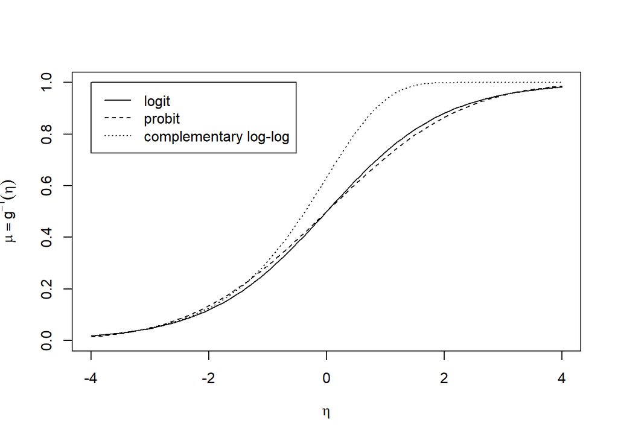

```r
# Comparing the different link functions
mu.logit <- function(eta) 1/(1 + exp(-eta))
mu.probit <- function(eta) pnorm(eta, 0, pi/sqrt(3))
mu.cloglog <- function(eta) 1 - exp(-exp(eta))

plot(mu.logit, (-4): 4, xlim = c(-4, 4), ylim = c(0,1), xlab = expression(eta), ylab = expression(mu == g^-1 * (eta)))
curve(mu.probit, (-4):4, add = TRUE, lty = 2)
curve(mu.cloglog, (-4):4, add = TRUE, lty = 3)
legend(-4, 1, c("logit", "probit", "complementary log-log"), lty = 1:3)
```

## Interpretation

Consider the logistic regression model
$$log(\frac{p_i}{1 − p_i})= β_0 + β_1 x_{1i}$$
If we increase x1 by one unit
$$log( \frac{pi}{1−pi}) = β_0 + β_1(x_{1i} + 1) = β_0 + β_1 x_{1i} + β_1$$
So
$$\frac{p_i}{1 − p_i} = exp(β_0 + β_1 x_{1i})exp(β_1)$$
the odds are multiplied by $exp(β_1)$.

# Implementation in R

## Case control study data

In the mid-80s a case-control study on risk factors for malignant melanoma was conducted in Denmark (Osterlind et al. The Danish case-control study of cutaneous malignant melanoma I: Importance of host factors. Int J Cancer 1988; 42: 200-206). The cases were patients with skin melanoma (excluding lentigo melanoma), newly diagnosed from 1 Oct, 1982 to 31 March, 1985, aged 20-79, from East Denmark, and they were identified from the Danish Cancer Registry. The controls (twice as many as cases) were drawn from the residents of East Denmark in April, 1984, as a random sample stratified by sex and age (within the same 5 year age group) to reflect the sex and age distribution of the cases.

| Variable | Units or Coding | Type | Name |
| --- | --- | --- | --- |
| Case-control status | 1=case, 0=control | numeric | cc |
| Sex | 1=male, 2=female | numeric | sex |
| Age at interview | age in years | numeric | age |
| Skin complexion | 0=dark, 1=medium, 2=light | numeric | skin |
| Hair colour | 0=dark brown/black, 1=light brown, 2=blonde, 3=red | numeric | hair |
| eye colour | 0=brown, 1=grey, green, 2=blue | numeric | eyes |
| Freckles | 1=many, 2=some, 3=none | numeric | freckles |
| Naevi, small | no. naevi < 5mm | numeric | nvsmall |
| Naevi, largs | no. naevi >= 5mm | numeric | nvlarge |

```r
# reading Data
mel <- read.table("http://bendixcarstensen.com/SPE/data/melanoma.dat", header = T, na.string = ".")
str(mel)
```

```
## 'data.frame':    1400 obs. of  9 variables:
##  $ cc      : int  1 1 1 0 1 0 0 0 0 1 ...
##  $ sex     : int  2 1 2 2 2 2 2 1 2 2 ...
##  $ age     : int  71 68 42 66 36 68 68 39 75 49 ...
##  $ skin    : int  2 2 1 0 1 2 0 2 2 2 ...
##  $ hair    : int  0 0 1 2 0 2 0 0 0 1 ...
##  $ eyes    : int  2 2 2 1 2 2 1 2 2 2 ...
##  $ freckles: int  2 1 3 2 3 2 2 2 1 2 ...
##  $ nvsmall : int  2 3 22 0 1 0 0 3 5 6 ...
##  $ nvlarge : int  0 0 1 0 0 0 0 0 0 0 ...
```

```r
head(mel)
```

```
##   cc sex age skin hair eyes freckles nvsmall nvlarge
## 1  1   2  71    2    0    2        2       2       0
## 2  1   1  68    2    0    2        1       3       0
## 3  1   2  42    1    1    2        3      22       1
## 4  0   2  66    0    2    1        2       0       0
## 5  1   2  36    1    0    2        3       1       0
## 6  0   2  68    2    2    2        2       0       0
```

```r
# Housekeeping
# Convert sex, skin, hair, eye into factor variables
source("http://bendixcarstensen.com/SPE/data/melanoma-house.r")
str(mel)
```

```
## 'data.frame':    1400 obs. of  13 variables:
##  $ cc      : int  1 1 1 0 1 0 0 0 0 1 ...
##  $ sex     : Factor w/ 2 levels "M","F": 2 1 2 2 2 2 2 1 2 2 ...
##  $ age     : int  71 68 42 66 36 68 68 39 75 49 ...
##  $ skin    : Factor w/ 3 levels "dark","medium",..: 3 3 2 1 2 3 1 3 3 3 ...
##  $ hair    : Factor w/ 4 levels "dark","light_brown",..: 1 1 2 3 1 3 1 1 1 2 ...
##  $ eyes    : Factor w/ 3 levels "brown","grey-green",..: 3 3 3 2 3 3 2 3 3 3 ...
##  $ freckles: Factor w/ 3 levels "none","some",..: 2 3 1 2 1 2 2 2 3 2 ...
##  $ nvsmall : int  2 3 22 0 1 0 0 3 5 6 ...
##  $ nvlarge : int  0 0 1 0 0 0 0 0 0 0 ...
##  $ age.cat : Factor w/ 6 levels "[20,30)","[30,40)",..: 6 5 3 5 2 5 5 2 6 3 ...
##  $ hair2   : Factor w/ 2 levels "dark","other": 1 1 2 2 1 2 1 1 1 2 ...
##  $ nvsma4  : Factor w/ 4 levels "[0,1)","[1,2)",..: 3 3 4 1 2 1 1 3 4 4 ...
##  $ nvlar3  : Factor w/ 3 levels "[0,1)","[1,2)",..: 1 1 2 1 1 1 1 1 1 1 ...
```

## Exploring binary data

```r
# Exploring binary data
# When the explanatory variables are categorical, a simple approach is to calculate proportions within subgroups of the data.
# When some of the explantory variables are continuous, plots can be more helpful.

# skin
with(mel, table(cc,skin)) # number of cases and controls by skin color
```

```
##    skin
## cc  dark medium light
##   0  232    391   296
##   1   86    203   182
```

```r
stat.table(index = skin, contents = ratio(cc,1-cc), data = mel) # odds of being a case by skin color
```

```
##  -------------------
##  skin     ratio(cc,
##             1 - cc)
##  -------------------
##  dark          0.37
##  medium        0.52
##  light         0.61
##  -------------------
```

```r
# eyes
with(mel, table(cc,eyes))
```

```
##    eyes
## cc  brown grey-green blue
##   0   123        312  488
##   1    64        138  269
```

```r
stat.table(index = eyes, contents = ratio(cc,1-cc), data = mel)
```

```
##  -----------------------
##  eyes         ratio(cc,
##                 1 - cc)
##  -----------------------
##  brown             0.52
##  grey-green        0.44
##  blue              0.55
##  -----------------------
```

```r
# freckles
with(mel, table(cc,freckles))
```

```
##    freckles
## cc  none some many
##   0  466  343  114
##   1  167  183  123
```

```r
stat.table(index = freckles, contents = ratio(cc,1-cc), data = mel)
```

```
##  ---------------------
##  freckles   ratio(cc,
##               1 - cc)
##  ---------------------
##  none            0.36
##  some            0.53
##  many            1.08
##  ---------------------
```

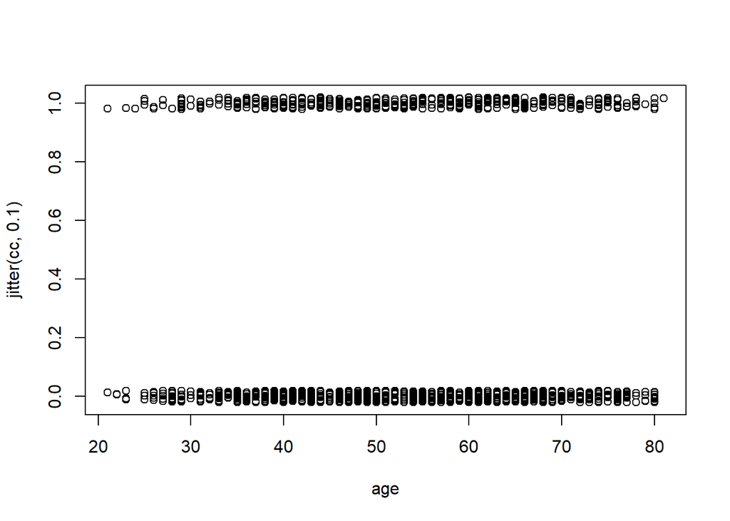

```r
# age
# plot(cc ∼ age, data = mel) # Simple scatterplot are not that helpful
plot(jitter(cc, 0.1) ∼ age, data = mel) # can be improved by using jitter
```

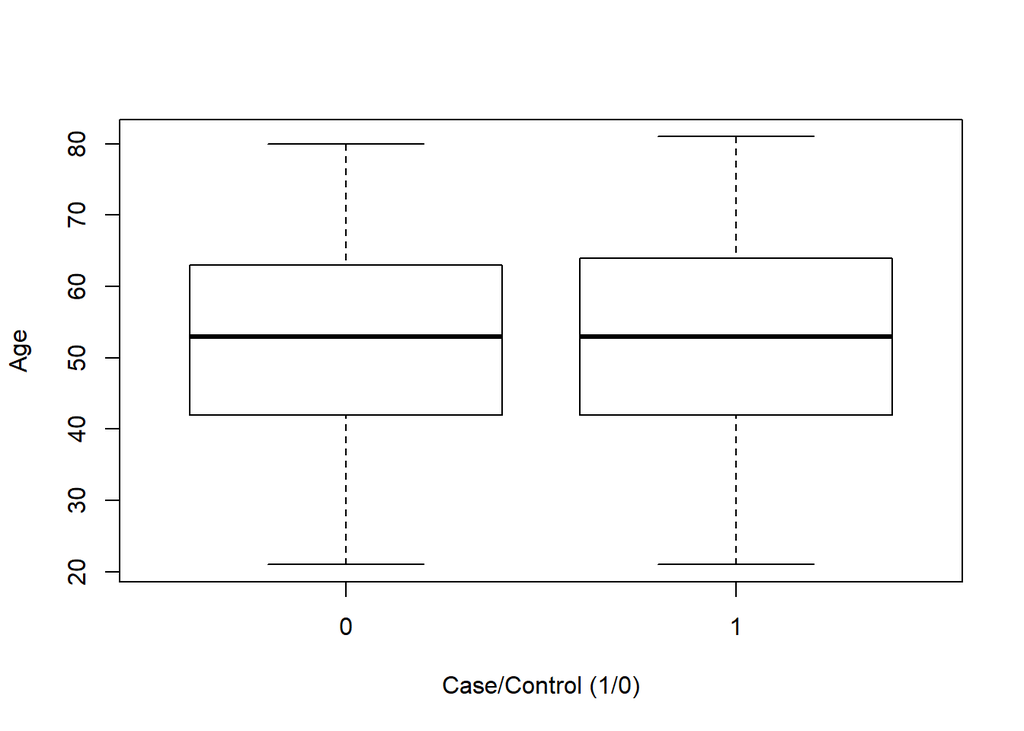

```r
boxplot(age ∼ cc, xlab = "Case/Control (1/0)", ylab = "Age", data = mel) # an alternative to scatter plot is to use a box plot
```

```r
# Note crude estimates of the odds ratio can be derived for the categorical data from tables above
```

## Modeling binary data

```r
# Calculate effects of an exposure on a response

# Effects are calculated as differences in means for a metric response,
# odds ratios/relative risks for a binary response,
# and rate ratios/rate differences for a failure or count response.

# The k-1 effects for a categorical exposure with k levels are relative to a baseline which, by default, is the first level.

effx(response = cc, type ="binary", exposure = skin, data = mel)
```

```
## ---------------------------------------------------------------------------
## response      :  cc
## type          :  binary
## exposure      :  skin
##
## skin is a factor with levels: dark / medium / light
## baseline is  dark
## effects are measured as odds ratios
## ---------------------------------------------------------------------------
##
## effect of skin on cc
## number of observations  1390
##
##                Effect 2.5% 97.5%
## medium vs dark   1.40 1.04  1.89
## light vs dark    1.66 1.22  2.26
##
## Test for no effects of exposure on 2 df: p-value= 0.00499
```

```r
effx(response = cc, type ="binary", exposure = eyes, data = mel)
```

```
## ---------------------------------------------------------------------------
## response      :  cc
## type          :  binary
## exposure      :  eyes
##
## eyes is a factor with levels: brown / grey-green / blue
## baseline is  brown
## effects are measured as odds ratios
## ---------------------------------------------------------------------------
##
## effect of eyes on cc
## number of observations  1394
##
##                     Effect  2.5% 97.5%
## grey-green vs brown   0.85 0.592  1.22
## blue vs brown         1.06 0.756  1.48
##
## Test for no effects of exposure on 2 df: p-value= 0.22
```

```r
effx(response = cc, type ="binary", exposure = freckles, data = mel)
```

```
## ---------------------------------------------------------------------------
## response      :  cc
## type          :  binary
## exposure      :  freckles
##
## freckles is a factor with levels: none / some / many
## baseline is  none
## effects are measured as odds ratios
## ---------------------------------------------------------------------------
##
## effect of freckles on cc
## number of observations  1396
##
##              Effect 2.5% 97.5%
## some vs none   1.49 1.16  1.92
## many vs none   3.01 2.21  4.11
##
## Test for no effects of exposure on 2 df: p-value= 2.15e-11
```

```r
# The function effx gives the same ouptput as using GLM with binomial family and logit link
```

```r
# Modeling for binary data

# GLM with binomial family and logit link
mf <- glm(cc ~ freckles, family ="binomial", data = mel)
# Summary
summary(mf)
```

```
##
## Call:
## glm(formula = cc ~ freckles, family = "binomial", data = mel)
##
## Deviance Residuals:
##     Min       1Q   Median       3Q      Max
## -1.2098  -0.9247  -0.7827   1.4531   1.6325
##
## Coefficients:
##              Estimate Std. Error z value Pr(>|z|)
## (Intercept)  -1.02619    0.09019 -11.378  < 2e-16 ***
## frecklessome  0.39795    0.12851   3.097  0.00196 **
## frecklesmany  1.10218    0.15823   6.966 3.27e-12 ***
## ---
## Signif. codes:  0 '***' 0.001 '**' 0.01 '*' 0.05 '.' 0.1 ' ' 1
##
## (Dispersion parameter for binomial family taken to be 1)
##
##     Null deviance: 1787.6  on 1395  degrees of freedom
## Residual deviance: 1738.5  on 1393  degrees of freedom
##   (4 observations deleted due to missingness)
## AIC: 1744.5
##
## Number of Fisher Scoring iterations: 4
```

```r
# Odds ratio/relative risks
round(ci.exp( mf ),2)
```

```
##              exp(Est.) 2.5% 97.5%
## (Intercept)       0.36 0.30  0.43
## frecklessome      1.49 1.16  1.92
## frecklesmany      3.01 2.21  4.11
```

```r
# Controlling with age and sex
# Using effx
effx(cc, type = "binary", exposure = freckles, control = list(age.cat,sex), data = mel)
```

```
## ---------------------------------------------------------------------------
## response      :  cc
## type          :  binary
## exposure      :  freckles
## control vars  :  age.cat sex
##
## freckles is a factor with levels: none / some / many
## baseline is  none
## effects are measured as odds ratios
## ---------------------------------------------------------------------------
##
## effect of freckles on cc
## controlled for age.cat sex
##
## number of observations  1396
##
##              Effect 2.5% 97.5%
## some vs none   1.51 1.17  1.95
## many vs none   3.07 2.24  4.22
##
## Test for no effects of exposure on 2 df: p-value= 2.55e-11
```

```r
# Using glm
mfas <- glm(cc ~ freckles + age.cat + sex, family = "binomial", data = mel) # this gives same result as using effx with control
round(ci.exp(mfas),2)
```

```
##                exp(Est.) 2.5% 97.5%
## (Intercept)         0.41 0.23  0.72
## frecklessome        1.51 1.17  1.95
## frecklesmany        3.07 2.24  4.22
## age.cat[30,40)      0.90 0.49  1.67
## age.cat[40,50)      0.91 0.51  1.62
## age.cat[50,60)      0.97 0.54  1.75
## age.cat[60,70)      0.82 0.45  1.48
## age.cat[70,85)      0.89 0.48  1.65
## sexF                0.94 0.74  1.19
```

```r
summary(mfas)
```

```
##
## Call:
## glm(formula = cc ~ freckles + age.cat + sex, family = "binomial",
##     data = mel)
##
## Deviance Residuals:
##     Min       1Q   Median       3Q      Max
## -1.2630  -0.9123  -0.7732   1.3877   1.6914
##
## Coefficients:
##                Estimate Std. Error z value Pr(>|z|)
## (Intercept)    -0.89385    0.29048  -3.077  0.00209 **
## frecklessome    0.41206    0.13030   3.163  0.00156 **
## frecklesmany    1.12242    0.16184   6.936 4.05e-12 ***
## age.cat[30,40) -0.10515    0.31393  -0.335  0.73767
## age.cat[40,50) -0.09830    0.29765  -0.330  0.74120
## age.cat[50,60) -0.02955    0.30155  -0.098  0.92194
## age.cat[60,70) -0.20094    0.30216  -0.665  0.50604
## age.cat[70,85) -0.11732    0.31666  -0.370  0.71101
## sexF           -0.06223    0.11910  -0.523  0.60132
## ---
## Signif. codes:  0 '***' 0.001 '**' 0.01 '*' 0.05 '.' 0.1 ' ' 1
##
## (Dispersion parameter for binomial family taken to be 1)
##
##     Null deviance: 1787.6  on 1395  degrees of freedom
## Residual deviance: 1737.1  on 1387  degrees of freedom
##   (4 observations deleted due to missingness)
## AIC: 1755.1
##
## Number of Fisher Scoring iterations: 4
```

```r
# Testing for no effect of an exposure
# to test for no effect at all of freckles you need a likelihood ratio test.
# This involves fitting two models, one without freckles and one with, and recording the change in deviance.

# Because of NAs in freckles we need to restrict the 1st model to people who have non NA freckles
mas <- glm(cc ~ age.cat + sex, family = "binomial", data = subset(mel, !is.na(freckles)) )
anova(mas, mfas, test = "Chisq")
```

```
## Analysis of Deviance Table
##
## Model 1: cc ~ age.cat + sex
## Model 2: cc ~ freckles + age.cat + sex
##   Resid. Df Resid. Dev Df Deviance  Pr(>Chi)
## 1      1389     1785.9
## 2      1387     1737.1  2   48.786 2.549e-11 ***
## ---
## Signif. codes:  0 '***' 0.001 '**' 0.01 '*' 0.05 '.' 0.1 ' ' 1
```

The change in residual deviance is 1785.9 - 1737.1 = 48.8 on 1389 - 1387 = 2 degrees of freedom. The P-value corresponding to this change is obtained from the upper tail of the cumulative distribution of the 2-distribution with 2 df:

```r
1 - pchisq(48.786, 2)
```

```
## [1] 2.548328e-11
```